# Week 3: Regression

# View the first few rows

```r
head(cars)
```

|  | speed | dist |
| --- | --- | --- |
| 1 | 4 | 2 |
| 2 | 4 | 10 |
| 3 | 7 | 4 |
| 4 | 7 | 22 |
| 5 | 8 | 16 |
| 6 | 9 | 10 |

```r
NA
```

# Scatter plot to visualise linear relationships

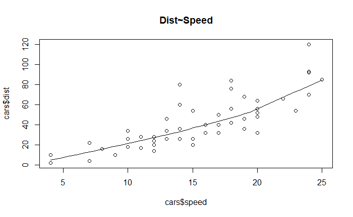

```r
scatter.smooth(x = cars$speed, y = cars$dist, main = "Dist~Speed") #Scatterplot
```

```r
# If the line goes up or down there is a linear relationship
```

A scatter plot in R is a graphical representation used to visualize the relationship between two continuous variables. Each point on the plot represents an observation in the dataset, with its position determined by the values of the two variables.

# Boxplot to check for outliers

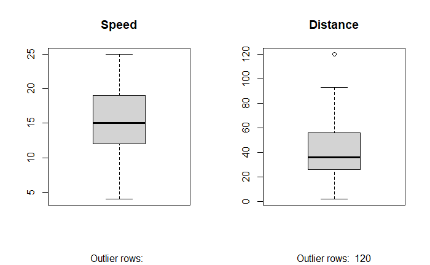

```r
par(mfrow = c(1, 2)) # Divide graph area into 2 columns

boxplot(cars$speed, main = "Speed", sub = paste("Outlier rows: ", boxplot.stats(cars$speed)$out)) #box plot for speed

boxplot(cars$dist, main = "Distance", sub = paste("Outlier rows: ", boxplot.stats(cars$dist)$out)) # boxplot for distance
```

```r
NA
```

Interpretation Box Width: Indicates the spread of the middle 50% of the data. Whiskers: Show the range of the data within 1.5 * IQR. Outliers: Highlight unusual data points that may need further investigation.

# Density plot to check check response variable is close to normality

```r
library(e1071)

par(mfrow = c(1, 2)) # Divide the graph area in 2 columns

plot(density(cars$speed), main = "Density Plot Speed", ylab = "Frequency",
     sub = paste("Skewness",
                 round(e1071::skewness(cars$speed), 2))) # density plot for speed

polygon(density(cars$speed), col = "red")
```

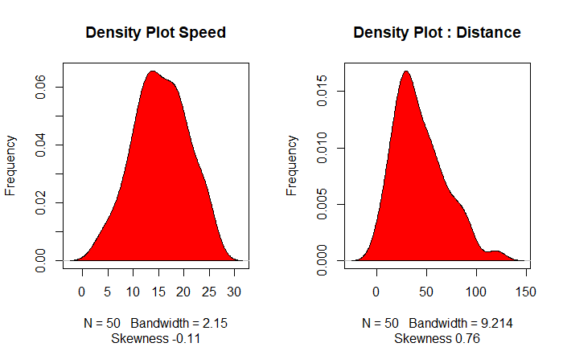

```r
plot(density(cars$dist), main = "Density Plot : Distance", ylab = "Frequency",
     sub = paste("Skewness", round(e1071::skewness(cars$dist), 2))) # density plot for dist
polygon(density(cars$dist), col = "red")
```

```r
NA
NA
```

Interpretation Peaks: Peaks in the density plot indicate where data points are concentrated. Width: The width of the density plot shows the spread of the data.

# Correlation

```r
cor(cars$speed, cars$dist) # calculate correlation between speed and distance
```

```
[1] 0.8068949
```

# Building a Linear Model

```r
linearMod <- lm(dist ~ speed, data = cars) # build a linear model with the lm()function and formula within

print(linearMod)
```

```
Call:
lm(formula = dist ~ speed, data = cars)

Coefficients:
(Intercept)        speed
    -17.579        3.932
```

# Linear Regression Diagnostics

```r
summary(linearMod)
```

```
Call:
lm(formula = dist ~ speed, data = cars)

Residuals:
    Min      1Q  Median      3Q     Max
-29.069  -9.525  -2.272   9.215  43.201

Coefficients:
            Estimate Std. Error t value Pr(>|t|)
(Intercept) -17.5791     6.7584  -2.601   0.0123 *
speed         3.9324     0.4155   9.464 1.49e-12 ***
---
Signif. codes:  0 ‘***’ 0.001 ‘**’ 0.01 ‘*’ 0.05 ‘.’ 0.1 ‘ ’ 1

Residual standard error: 15.38 on 48 degrees of freedom
Multiple R-squared:  0.6511,    Adjusted R-squared:  0.6438
F-statistic: 89.57 on 1 and 48 DF,  p-value: 1.49e-12
```

What is a p-value?

Definition: The p-value is the probability of obtaining test results at least as extreme as the observed results, assuming that the null hypothesis is true.

Purpose: It helps you decide whether to reject the null hypothesis. A low p-value indicates that the observed data is unlikely under the null hypothesis, suggesting that the alternative hypothesis may be true. Interpreting p-values

Common Thresholds: p < 0.05: Strong evidence against the null hypothesis, so you reject the null hypothesis. p < 0.01: Very strong evidence against the null hypothesis. p < 0.001: Extremely strong evidence against the null hypothesis. p > 0.05: Weak evidence against the null hypothesis, so you fail to reject the null hypothesis

In R, a t-value is a statistic used in t-tests to determine if there is a significant difference between the means of two groups. It is calculated as the ratio of the difference between the sample mean and the population mean to the standard error of the sample mean.

# Create training and test data

```r
set.seed(100) # Setting the seed reproduces results of random sampling

trainingRowIndex <- sample(1:nrow(cars), 0.8*nrow(cars)) # row indices for training data
trainingData <- cars[trainingRowIndex, ] # model training data
testData <- cars[-trainingRowIndex, ] #test data
```

# Develop the model on the training data to predict distance on test data

# Build the model on the training data

```r
lmMod <- lm(dist ~ speed, data = trainingData) # lm(linear model and the formula (dist over speed and data source))
distPred <- predict(lmMod, testData) # predict distance
```

# Review diagnostic measures

```r
summary(lmMod)
```

```
Call:
lm(formula = dist ~ speed, data = trainingData)

Residuals:
    Min      1Q  Median      3Q     Max
-24.726 -11.242  -2.564  10.436  40.565

Coefficients:
            Estimate Std. Error t value Pr(>|t|)
(Intercept) -20.1796     7.8254  -2.579   0.0139 *
speed         4.2582     0.4947   8.608 1.85e-10 ***
---
Signif. codes:  0 ‘***’ 0.001 ‘**’ 0.01 ‘*’ 0.05 ‘.’ 0.1 ‘ ’ 1

Residual standard error: 15.49 on 38 degrees of freedom
Multiple R-squared:  0.661, Adjusted R-squared:  0.6521
F-statistic: 74.11 on 1 and 38 DF,  p-value: 1.848e-10
```

# Calculate prediction accuracy and error rates

```r
actuals_preds <- data.frame(cbind(actuals = testData$dist,
                                  predicteds = distPred)) # make actuals_predicteds dataframe

correlation_accuracy <- cor(actuals_preds)

head(actuals_preds)
```

|  | actuals | predicteds |
| --- | --- | --- |
| 3 | 4 | 9.627845 |
| 5 | 16 | 13.886057 |
| 17 | 34 | 35.177120 |
| 24 | 20 | 43.693545 |
| 28 | 40 | 47.951757 |
| 32 | 42 | 56.468182 |

```r
#MinMaxAccuracy

min_max_accuracy <- mean(apply(actuals_preds, 1, min) / apply(actuals_preds, 1, max))

# Mean Absolute Percentage Error

mape <- mean(abs((actuals_preds$predicteds - actuals_preds$actuals)) / actuals_preds$actuals)

min_max_accuracy
```

```
[1] 0.7311131
```

```r
mape
```

```
[1] 0.4959096
```

# k-Fold Cross Validation

[output not shown]

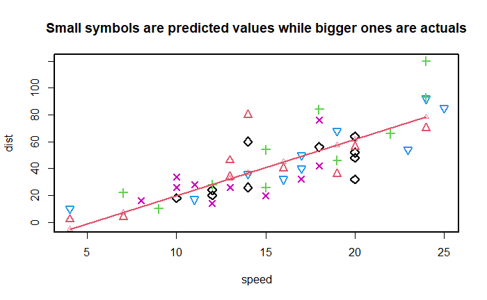

```r
library(DAAG)

par(mfrow = c(1, 1))

CVlm(data = cars, form.lm = dist ~ speed, m = 5, dots = FALSE, seed = 29,
     legeng.pos = "topleft", printit = FALSE, cex = 0.5,
     main = "Small symbols are predicted values while bigger ones are actuals")
```

Y = mX + c Where: m = slope of straight line and c = Y-intercept

# Linear Regression using AirQuality Dataset

```r
require("datasets")
data("airquality")
str(airquality)
```

```
'data.frame':   153 obs. of  6 variables:
 $ Ozone  : int  41 36 12 18 NA 28 23 19 8 NA ...
 $ Solar.R: int  190 118 149 313 NA NA 299 99 19 194 ...
 $ Wind   : num  7.4 8 12.6 11.5 14.3 14.9 8.6 13.8 20.1 8.6 ...
 $ Temp   : int  67 72 74 62 56 66 65 59 61 69 ...
 $ Month  : int  5 5 5 5 5 5 5 5 5 5 ...
 $ Day    : int  1 2 3 4 5 6 7 8 9 10 ...
```